# Slingshot: Trajectory Inference for Single-Cell Data

Kelly Street

2025-07-12

# 1 Introduction

This vignette will demonstrate a full single-cell lineage analysis workflow, with particular emphasis on the processes of lineage reconstruction and pseudotime inference. We will make use of the `slingshot` package proposed in (Street et al. 2017) and show how it may be applied in a broad range of settings.

The goal of `slingshot` is to use clusters of cells to uncover global structure and convert this structure into smooth lineages represented by one-dimensional variables, called “pseudotime.” We provide tools for learning cluster relationships in an unsupervised or semi-supervised manner and constructing smooth curves representing each lineage, along with visualization methods for each step.

## 1.1 Overview

The minimal input to `slingshot` is a matrix representing the cells in a reduced-dimensional space and a vector of cluster labels. With these two inputs, we then:

- Identify the global lineage structure by constructing an minimum spanning tree (MST) on the clusters, with the `getLineages` function.
- Construct smooth lineages and infer pseudotime variables by fitting simultaneous principal curves with the `getCurves` function.
- Assess the output of each step with built-in visualization tools.

## 1.2 Datasets

We will work with two simulated datasets in this vignette. The first (referred to as the “single-trajectory” dataset) is generated below and designed to represent a single lineage in which one third of the genes are associated with the transition. This dataset will be contained in a `SingleCellExperiment` object (Lun and Risso 2017) and will be used to demonstrate a full “start-to-finish” workflow.

```r
# generate synthetic count data representing a single lineage
means <- rbind(
    # non-DE genes
    matrix(rep(rep(c(0.1,0.5,1,2,3), each = 300),100),
        ncol = 300, byrow = TRUE),
    # early deactivation
    matrix(rep(exp(atan( ((300:1)-200)/50 )),50), ncol = 300, byrow = TRUE),
    # late deactivation
    matrix(rep(exp(atan( ((300:1)-100)/50 )),50), ncol = 300, byrow = TRUE),
    # early activation
    matrix(rep(exp(atan( ((1:300)-100)/50 )),50), ncol = 300, byrow = TRUE),
    # late activation
    matrix(rep(exp(atan( ((1:300)-200)/50 )),50), ncol = 300, byrow = TRUE),
    # transient
    matrix(rep(exp(atan( c((1:100)/33, rep(3,100), (100:1)/33) )),50),
        ncol = 300, byrow = TRUE)
)
counts <- apply(means,2,function(cell_means){
    total <- rnbinom(1, mu = 7500, size = 4)
    rmultinom(1, total, cell_means)
})
rownames(counts) <- paste0('G',1:750)
colnames(counts) <- paste0('c',1:300)
sce <- SingleCellExperiment(assays = List(counts = counts))
```

The second dataset (the “bifurcating” dataset) consists of a matrix of coordinates (as if obtained by PCA, ICA, diffusion maps, etc.) along with cluster labels generated by $k$-means clustering. This dataset represents a bifurcating trajectory and it will allow us to demonstrate some of the additional functionality offered by `slingshot`.

```r
library(slingshot, quietly = FALSE)
data("slingshotExample")
rd <- slingshotExample$rd
cl <- slingshotExample$cl

dim(rd) # data representing cells in a reduced dimensional space
```

```
## [1] 140   2
```

```r
length(cl) # vector of cluster labels
```

```
## [1] 140
```

# 2 Upstream Analysis

## 2.1 Gene Filtering

To begin our analysis of the single lineage dataset, we need to reduce the dimensionality of our data and filtering out uninformative genes is a typical first step. This will greatly improve the speed of downstream analyses, while keeping the loss of information to a minimum.

For the gene filtering step, we retained any genes robustly expressed in at least enough cells to constitute a cluster, making them potentially interesting cell-type marker genes. We set this minimum cluster size to 10 cells and define a gene as being “robustly expressed” if it has a simulated count of at least 3 reads.

```r
# filter genes down to potential cell-type markers
# at least M (15) reads in at least N (15) cells
geneFilter <- apply(assays(sce)$counts,1,function(x){
    sum(x >= 3) >= 10
})
sce <- sce[geneFilter, ]
```

## 2.2 Normalization

Another important early step in most RNA-Seq analysis pipelines is the choice of normalization method. This allows us to remove unwanted technical or biological artifacts from the data, such as batch, sequencing depth, cell cycle effects, etc. In practice, it is valuable to compare a variety of normalization techniques and compare them along different evaluation criteria, for which we recommend the `scone` package (Cole and Risso 2018). We also note that the order of these steps may change depending on the choice of method. ZINB-WaVE (Risso et al. 2018) performs dimensionality reduction while accounting for technical variables and MNN (Haghverdi et al. 2018) corrects for batch effects after dimensionality reduction.

Since we are working with simulated data, we do not need to worry about batch effects or other potential confounders. Hence, we will proceed with full quantile normalization, a well-established method which forces each cell to have the same distribution of expression values.

```r
FQnorm <- function(counts){
    rk <- apply(counts,2,rank,ties.method='min')
    counts.sort <- apply(counts,2,sort)
    refdist <- apply(counts.sort,1,median)
    norm <- apply(rk,2,function(r){ refdist[r] })
    rownames(norm) <- rownames(counts)
    return(norm)
}
assays(sce)$norm <- FQnorm(assays(sce)$counts)
```

## 2.3 Dimensionality Reduction

The fundamental assumption of `slingshot` is that cells which are transcriptionally similar will be close to each other in some reduced-dimensional space. Since we use Euclidean distances in constructing lineages and measuring pseudotime, it is important to have a low-dimensional representation of the data.

There are many methods available for this task and we will intentionally avoid the issue of determining which is the “best” method, as this likely depends on the type of data, method of collection, upstream computational choices, and many other factors. We will demonstrate two methods of dimensionality reduction: principal components analysis (PCA) and uniform manifold approximation and projection (UMAP, via the `uwot` package).

When performing PCA, we do not scale the genes by their variance because we do not believe that all genes are equally informative. We want to find signal in the robustly expressed, highly variable genes, not dampen this signal by forcing equal variance across genes. When plotting, we make sure to set the aspect ratio, so as not to distort the perceived distances.

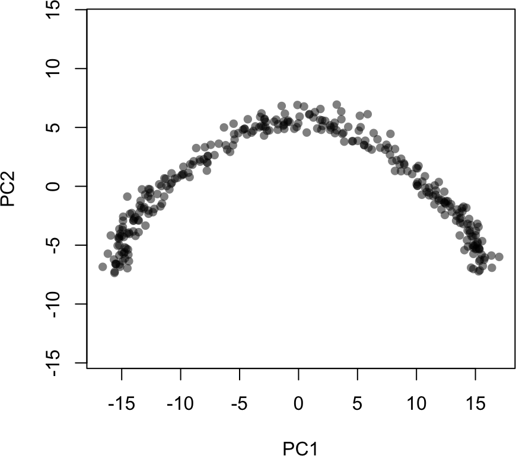

```r
pca <- prcomp(t(log1p(assays(sce)$norm)), scale. = FALSE)
rd1 <- pca$x[,1:2]

plot(rd1, col = rgb(0,0,0,.5), pch=16, asp = 1)
```

```r
library(uwot)
```

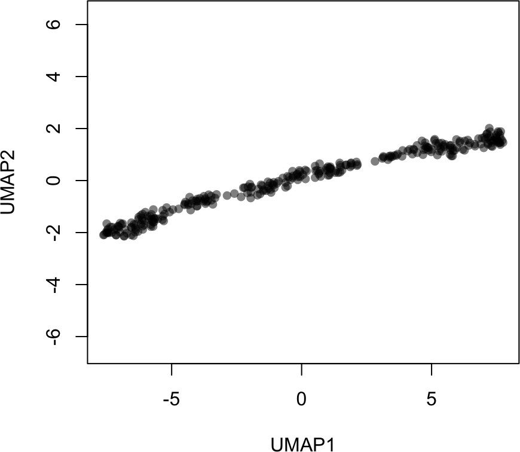

```r
rd2 <- uwot::umap(t(log1p(assays(sce)$norm)))
colnames(rd2) <- c('UMAP1', 'UMAP2')

plot(rd2, col = rgb(0,0,0,.5), pch=16, asp = 1)
```

We will add both dimensionality reductions to the `SingleCellExperiment` object, but continue our analysis focusing on the PCA results.

```r
reducedDims(sce) <- SimpleList(PCA = rd1, UMAP = rd2)
```

## 2.4 Clustering Cells

The final input to `slingshot` is a vector of cluster labels for the cells. If this is not provided, `slingshot` will treat the data as a single cluster and fit a standard principal curve. However, we recommend clustering the cells even in datasets where only a single lineage is expected, as it allows for the potential discovery of novel branching events.

The clusters identified in this step will be used to determine the global structure of the underlying lineages (that is, their number, when they branch off from one another, and the approximate locations of those branching events). This is different than the typical goal of clustering single-cell data, which is to identify all biologically relevant cell types present in the dataset. For example, when determining global lineage structure, there is no need to distinguish between immature and mature neurons since both cell types will, presumably, fall along the same segment of a lineage.

For our analysis, we implement two clustering methods which similarly assume that Euclidean distance in a low-dimensional space reflect biological differences between cells: Gaussian mixture modeling and $k$-means. The former is implemented in the `mclust` package (Scrucca et al. 2016) and features an automated method for determining the number of clusters based on the Bayesian information criterion (BIC).

```r
library(mclust, quietly = TRUE)
```

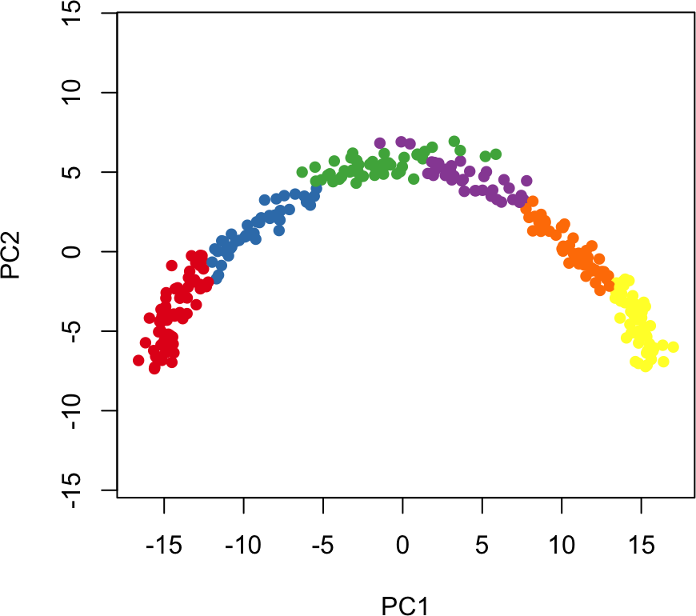

```r
cl1 <- Mclust(rd1)$classification
colData(sce)$GMM <- cl1

library(RColorBrewer)
plot(rd1, col = brewer.pal(9,"Set1")[cl1], pch=16, asp = 1)
```

While $k$-means does not have a similar functionality, we have shown in (Street et al. 2017) that simultaneous principal curves are quite robust to the choice of $k$, so we select a $k$ of 4 somewhat arbitrarily. If this is too low, we may miss a true branching event and if it is too high or there is an abundance of small clusters, we may begin to see spurious branching events.

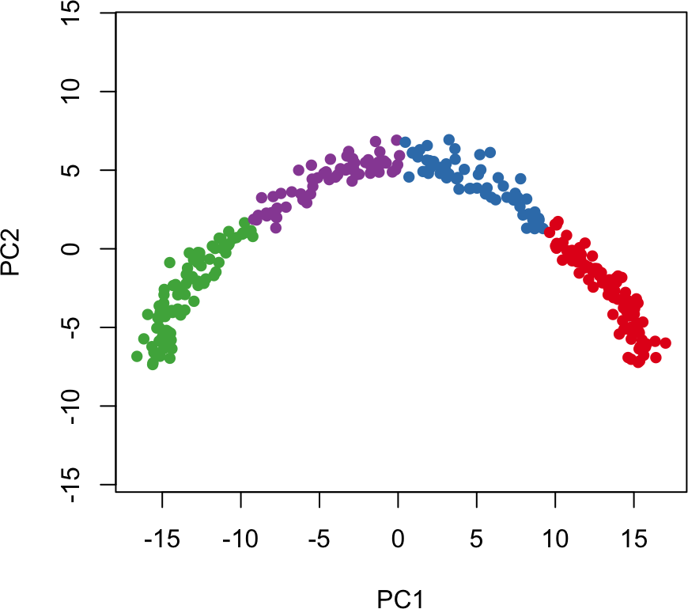

```r
cl2 <- kmeans(rd1, centers = 4)$cluster
colData(sce)$kmeans <- cl2

plot(rd1, col = brewer.pal(9,"Set1")[cl2], pch=16, asp = 1)
```

# 3 Using Slingshot

At this point, we have everything we need to run `slingshot` on our simulated dataset. This is a two-step process composed of identifying the global lineage structure with a cluster-based minimum spanning tree (MST) and fitting simultaneous principal curves to describe each lineage.

These two steps can be run separately with the `getLineages` and `getCurves` functions, or together with the wrapper function, `slingshot` (recommended). We will use the wrapper function for the analysis of the single-trajectory dataset, but demonstrate the usage of the individual functions later, on the bifurcating dataset.

The `slingshot` wrapper function performs both steps of trajectory inference in a single call. The necessary inputs are a reduced dimensional matrix of coordinates and a set of cluster labels. These can be separate objects or, in the case of the single-trajectory data, elements contained in a `SingleCellExperiment` object.

To run `slingshot` with the dimensionality reduction produced by PCA and cluster labels identified by Gaussian mixutre modeling, we would do the following:

```r
sce <- slingshot(sce, clusterLabels = 'GMM', reducedDim = 'PCA')
```

As noted above, if no clustering results are provided, it is assumed that all cells are part of the same cluster and a single curve will be constructed. If no dimensionality reduction is provided, `slingshot` will use the first element of the list returned by `reducedDims`.

The output is a `SingleCellExperiment` object with `slingshot` results incorporated. All of the results are stored in a `PseudotimeOrdering` object, which is added to the `colData` of the original object and can be accessed via `colData(sce)$slingshot`. Additionally, all inferred pseudotime variables (one per lineage) are added to the `colData`, individually. To extract all `slingshot` results in a single object, we can use either the `as.PseudotimeOrdering` or `as.SlingshotDataSet` functions, depending on the form in which we want it. `PseudotimeOrdering` objects are an extension of `SummarizedExperiment` objects, which are flexible containers that will be useful for most purposes. `SlingshotDataSet` objects are primarily used for visualization, as several plotting methods are included with the package. Below, we visuzalize the inferred lineage for the single-trajectory data with points colored by pseudotime.

```r
summary(sce$slingPseudotime_1)
```

```
##    Min. 1st Qu.  Median    Mean 3rd Qu.    Max.
##   0.000   8.642  21.363  21.483  34.418  42.877
```

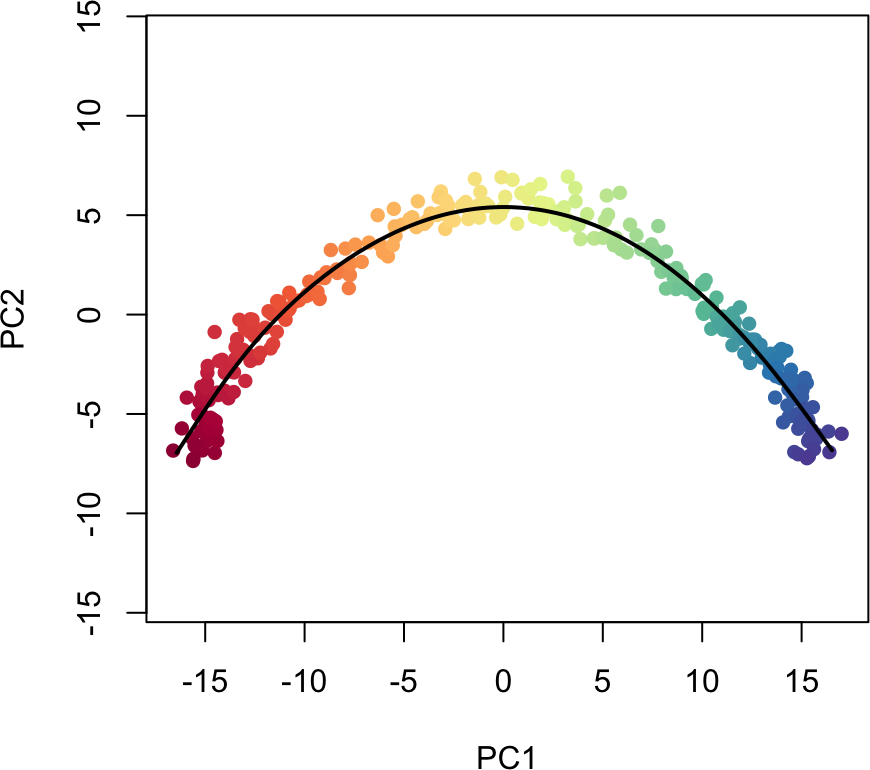

```r
library(grDevices)
colors <- colorRampPalette(brewer.pal(11,'Spectral')[-6])(100)
plotcol <- colors[cut(sce$slingPseudotime_1, breaks=100)]

plot(reducedDims(sce)$PCA, col = plotcol, pch=16, asp = 1)
lines(SlingshotDataSet(sce), lwd=2, col='black')
```

We can also see how the lineage structure was intially estimated by the cluster-based minimum spanning tree by using the `type` argument.

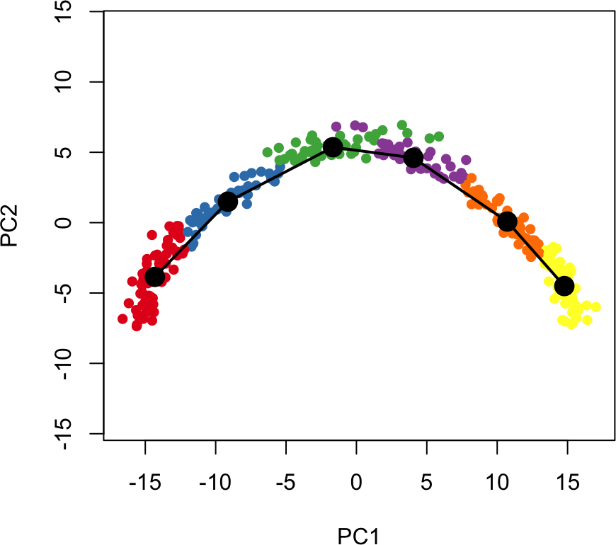

```r
plot(reducedDims(sce)$PCA, col = brewer.pal(9,'Set1')[sce$GMM], pch=16, asp = 1)
lines(SlingshotDataSet(sce), lwd=2, type = 'lineages', col = 'black')
```

# 4 Downstream Analysis

## 4.1 Identifying temporally dynamic genes

After running `slingshot`, we are often interested in finding genes that change their expression over the course of development. We will demonstrate this type of analysis using the `tradeSeq` package (Van den Berge et al. 2020).

For each gene, we will fit a general additive model (GAM) using a negative binomial noise distribution to model the (potentially nonlinear) relationshipships between gene expression and pseudotime. We will then test for significant associations between expression and pseudotime using the `associationTest`.

```r
library(tradeSeq)

# fit negative binomial GAM
sce <- fitGAM(sce)

# test for dynamic expression
ATres <- associationTest(sce)
```

We can then pick out the top genes based on p-values and visualize their expression over developmental time with a heatmap. Here we use the top 250 most dynamically expressed genes.

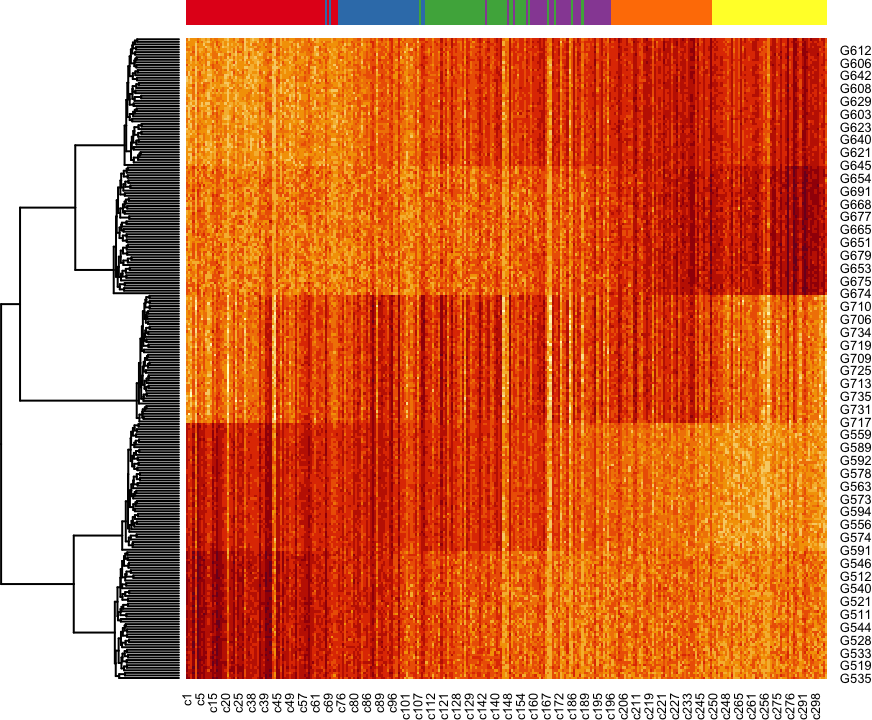

```r
topgenes <- rownames(ATres[order(ATres$pvalue), ])[1:250]
pst.ord <- order(sce$slingPseudotime_1, na.last = NA)
heatdata <- assays(sce)$counts[topgenes, pst.ord]
heatclus <- sce$GMM[pst.ord]

heatmap(log1p(heatdata), Colv = NA,
        ColSideColors = brewer.pal(9,"Set1")[heatclus])
```

# 5 Detailed Slingshot Functionality

Here, we provide further details and highlight some additional functionality of the `slingshot` package. We will use the included `slingshotExample` dataset for illustrative purposes. This dataset was designed to represent cells in a low dimensional space and comes with a set of cluster labels generated by $k$-means clustering. Rather than constructing a full `SingleCellExperiment` object, which requires gene-level data, we will use the low-dimensional matrix of coordinates directly and provide the cluster labels as an additional argument.

## 5.1 Identifying global lineage structure

The `getLineages` function takes as input an `n` $\times$ `p` matrix and a vector of clustering results of length `n`. It maps connections between adjacent clusters using a minimum spanning tree (MST) and identifies paths through these connections that represent lineages. The output of this function is a `PseudotimeOrdering` containing the inputs as well as the inferred MST (represented by an `igraph` object) and lineages (ordered vectors of cluster names).

This analysis can be performed in an entirely unsupervised manner or in a semi-supervised manner by specifying known initial and terminal point clusters. If we do not specify a starting point, `slingshot` selects one based on parsimony, maximizing the number of clusters shared between lineages before a split. If there are no splits or multiple clusters produce the same parsimony score, the starting cluster is chosen arbitrarily.

In the case of our simulated data, `slingshot` selects Cluster 1 as the starting cluster. However, we generally recommend the specification of an initial cluster based on prior knowledge (either time of sample collection or established gene markers). This specification will have no effect on how the MST is constructed, but it will impact how branching curves are constructed.

```r
lin1 <- getLineages(rd, cl, start.clus = '1')
lin1
```

```
## class: PseudotimeOrdering
## dim: 140 2
## metadata(3): lineages mst slingParams
## pathStats(2): pseudotime weights
## cellnames(140): cell-1 cell-2 ... cell-139 cell-140
## cellData names(2): reducedDim clusterLabels
## pathnames(2): Lineage1 Lineage2
## pathData names(0):
```

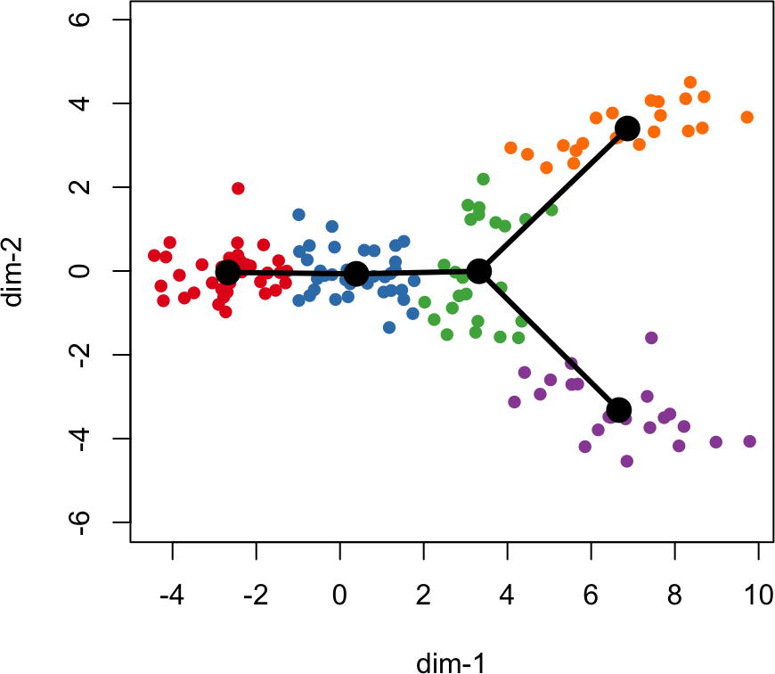

```r
plot(rd, col = brewer.pal(9,"Set1")[cl], asp = 1, pch = 16)
lines(SlingshotDataSet(lin1), lwd = 3, col = 'black')
```

At this step, `slingshot` also allows for the specification of known endpoints. Clusters which are specified as terminal cell states will be constrained to have only one connection when the MST is constructed (ie., they must be leaf nodes). This constraint could potentially impact how other parts of the tree are drawn, as shown in the next example where we specify Cluster 3 as an endpoint.

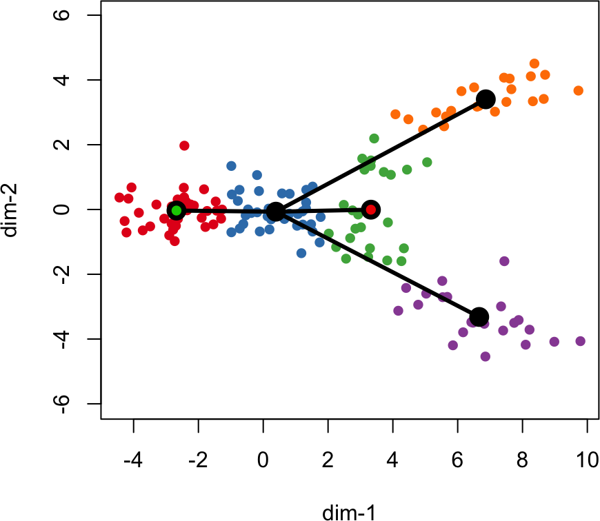

```r
lin2 <- getLineages(rd, cl, start.clus= '1', end.clus = '3')

plot(rd, col = brewer.pal(9,"Set1")[cl], asp = 1, pch = 16)
lines(SlingshotDataSet(lin2), lwd = 3, col = 'black', show.constraints = TRUE)
```

This type of supervision can be useful for ensuring that results are consistent with prior biological knowledge. Specifically, it can prevent known terminal cell fates from being categorized as transitory states.

There are a few additional arguments we could have passed to `getLineages` for greater control:

- `dist.method` is a character specifying how the distances between clusters should be computed. The default value is `"slingshot"`, which uses the distance between cluster centers, normalized by their full, joint covariance matrix. In the presence of small clusters (fewer cells than the dimensionality of the data), this will automatically switch to using the diagonal joint covariance matrix. Other options include `simple` (Euclidean), `scaled.full`, `scaled.diag`, and `mnn` (mutual nearest neighbor-based distance).
- `omega` is a granularity parameter, allowing the user to set an upper limit on connection distances. It represents the distance between every real cluster and an artificial `.OMEGA` cluster, which is removed after fitting the MST. This can be useful for identifying outlier clusters which are not a part of any lineage or for separating distinct trajectories. This may be a numeric argument or a logical value. A value of `TRUE` indicates that a heuristic of $1.5$ `(median edge length of unsupervised MST)` should be used, implying that the maximum allowable distance will be $3$ times that distance.

After constructing the MST, `getLineages` identifies paths through the tree to designate as lineages. At this stage, a lineage will consist of an ordered set of cluster names, starting with the root cluster and ending with a leaf. The output of `getLineages` is a `PseudotimeOrdering` which holds all of the inputs as well as a list of lineages and some additional information on how they were constructed. This object is then used as the input to the `getCurves` function.

## 5.2 Constructing smooth curves and ordering cells

In order to model development along these various lineages, we will construct smooth curves with the function `getCurves`. Using smooth curves based on all the cells eliminates the problem of cells projecting onto vertices of piece-wise linear trajectories and makes `slingshot` more robust to noise in the clustering results.

In order to construct smooth lineages, `getCurves` follows an iterative process similar to that of principal curves presented in (Hastie and Stuetzle 1989). When there is only a single lineage, the resulting curve is simply the principal curve through the center of the data, with one adjustment: the initial curve is constructed with the linear connections between cluster centers rather than the first prinicpal component of the data. This adjustment adds stability and typically hastens the algorithm’s convergence.

When there are two or more lineages, we add an additional step to the algorithm: averaging curves near shared cells. Both lineages should agree fairly well on cells that have yet to differentiate, so at each iteration we average the curves in the neighborhood of these cells. This increases the stability of the algorithm and produces smooth branching lineages.

```r
crv1 <- getCurves(lin1)
crv1
```

```
## class: PseudotimeOrdering
## dim: 140 2
## metadata(4): lineages mst slingParams curves
## pathStats(2): pseudotime weights
## cellnames(140): cell-1 cell-2 ... cell-139 cell-140
## cellData names(2): reducedDim clusterLabels
## pathnames(2): Lineage1 Lineage2
## pathData names(0):
```

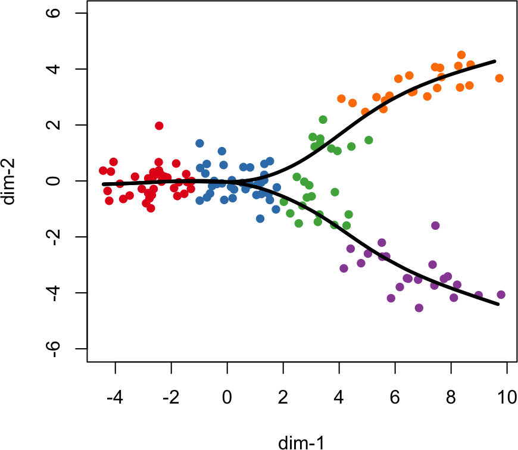

```r
plot(rd, col = brewer.pal(9,"Set1")[cl], asp = 1, pch = 16)
lines(SlingshotDataSet(crv1), lwd = 3, col = 'black')
```

The output of `getCurves` is an updated `PseudotimeOrdering` which now contains the simultaneous principal curves and additional information on how they were fit. The `slingPseudotime` function extracts a cells-by-lineages matrix of pseudotime values for each cell along each lineage, with `NA` values for cells that were not assigned to a particular lineage. The `slingCurveWeights` function extracts a similar matrix of weights assigning each cell to one or more lineages.

The curves objects can be accessed using the `slingCurves` function, which will return a list of `principal_curve` objects. These objects consist of the following slots:

- `s`: the matrix of points that make up the curve. These correspond to the orthogonal projections of the data points.
- `ord`: indices which can be used to put the cells along a curve in order based their projections.
- `lambda`: arclengths along the curve from the beginning to each cell’s projection. A matrix of these values is returned by the `slingPseudotime` function.
- `dist_ind`: the squared distances between data points and their projections onto the curve.
- `dist`: the sum of the squared projection distances.
- `w`: the vector of weights along this lineage. Cells that were unambiguously assigned to this lineage will have a weight of `1`, while cells assigned to other lineages will have a weight of `0`. It is possible for cells to have weights of `1` (or very close to 1) for multiple lineages, if they are positioned before a branching event. A matrix of these values is returned by the `slingCurveWeights` function.

## 5.3 Running Slingshot on large datasets

For large datasets, we highgly recommend using the `approx_points` argument with `slingshot` (or `getCurves`). This allows the user to specify the resolution of the curves (ie. the number of unique points). While the MST construction operates on clusters, the process of iteratively projecting all points onto one or more curves may become computationally burdensome as the size of the dataset grows. For this reason, we set the default value for `approx_points` to either $150$ or the number of cells in the dataset, whichever is smaller. This should greatly ease the computational cost of exploratory analysis while having minimal impact on the resulting trajectories.

For maximally “dense” curves, set `approx_points = FALSE`, and the curves will have as many points as there are cells in the dataset. However, note that each projection step in the iterative curve-fitting process will now have a computational complexity proportional to $n^2$ (where $n$ is the number of cells). In the presence of branching lineages, these dense curves will also affect the complexity of curve averaging and shrinkage.

We recommend a value of $100$-$200$, hence the default value of $150$. Note that restricting the number of unique points along the curve does *not* impose a similar limit on the number of unique pseudotime values, as demonstrated below. Even with an unrealistically low value of $5$ for `approx_points`, we still see a full color gradient from the pseudotime values:

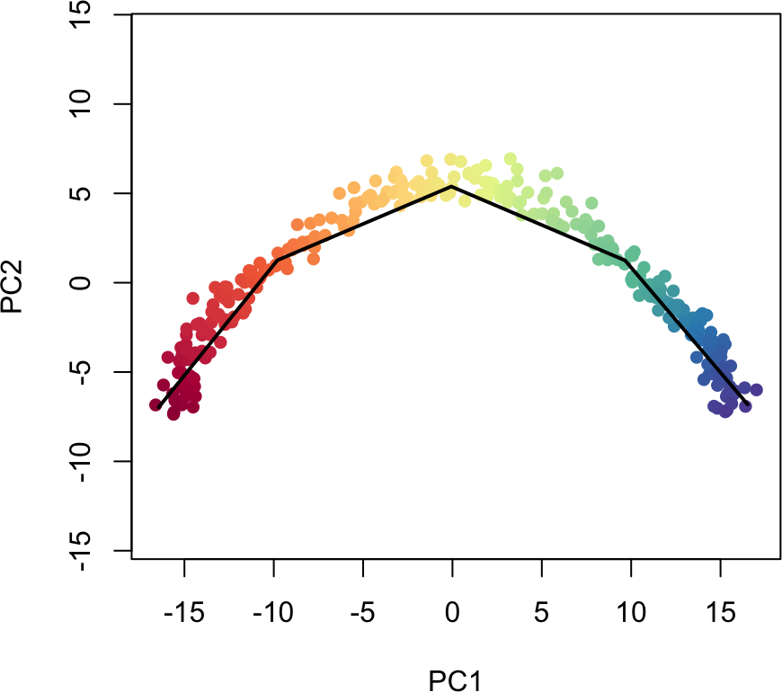

```r
sce5 <- slingshot(sce, clusterLabels = 'GMM', reducedDim = 'PCA',
                   approx_points = 5)

colors <- colorRampPalette(brewer.pal(11,'Spectral')[-6])(100)
plotcol <- colors[cut(sce5$slingPseudotime_1, breaks=100)]

plot(reducedDims(sce5)$PCA, col = plotcol, pch=16, asp = 1)
lines(SlingshotDataSet(sce5), lwd=2, col='black')
```

## 5.4 Multiple Trajectories

In some cases, we are interested in identifying multiple, disjoint trajectories. Slingshot handles this problem in the initial MST construction by introducing an artificial cluster, called `omega`. This artificial cluster is separated from every real cluster by a fixed length, meaning that the maximum distance between any two real clusters is twice this length. Practically, this sets a limit on the maximum edge length allowable in the MST. Setting `omega = TRUE` will implement a rule of thumb whereby the maximum allowable edge length is equal to $3$ times the median edge length of the MST constructed without the artificial cluster (note: this is equivalent to saying that the default value for `omega_scale` is $1.5$).

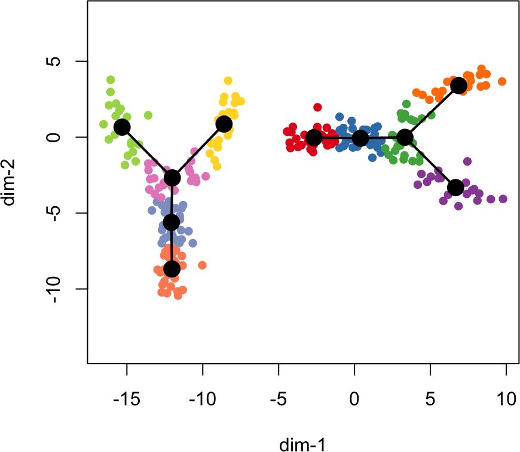

```r
rd2 <- rbind(rd, cbind(rd[,2]-12, rd[,1]-6))
cl2 <- c(cl, cl + 10)
pto2 <- slingshot(rd2, cl2, omega = TRUE, start.clus = c(1,11))

plot(rd2, pch=16, asp = 1,
     col = c(brewer.pal(9,"Set1"), brewer.pal(8,"Set2"))[cl2])
lines(SlingshotDataSet(pto2), type = 'l', lwd=2, col='black')
```

After fitting the MST, `slingshot` proceeds to fit simultaneous principal curves as usual, with each trajectory being handled separately.

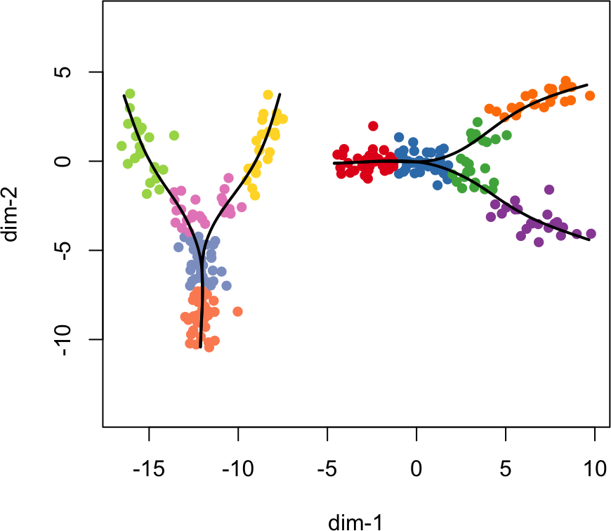

```r
plot(rd2, pch=16, asp = 1,
     col = c(brewer.pal(9,"Set1"), brewer.pal(8,"Set2"))[cl2])
lines(SlingshotDataSet(pto2), lwd=2, col='black')
```

## 5.5 Projecting Cells onto Existing Trajectories

Sometimes, we may want to use only a subset of the cells to determine a trajectory, or we may get new data that we want to project onto an existing trajectory. In either case, we will need a way to determine the positions of new cells along a previously constructed trajectory. For this, we can use the `predict` function (since this function is not native to `slingshot`, see `` ?`predict,PseudotimeOrdering-method` `` for documentation).

```r
# our original PseudotimeOrdering
pto <- sce$slingshot

# simulate new cells in PCA space
newPCA <- reducedDim(sce, 'PCA') + rnorm(2*ncol(sce), sd = 2)

# project onto trajectory
newPTO <- slingshot::predict(pto, newPCA)
```

This will yield a new, hybrid object with the trajectories (curves) from the original data, but the pseudotime values and weights for the new cells. For reference, the original cells are shown in grey below, but they are not included in the output from `predict`.

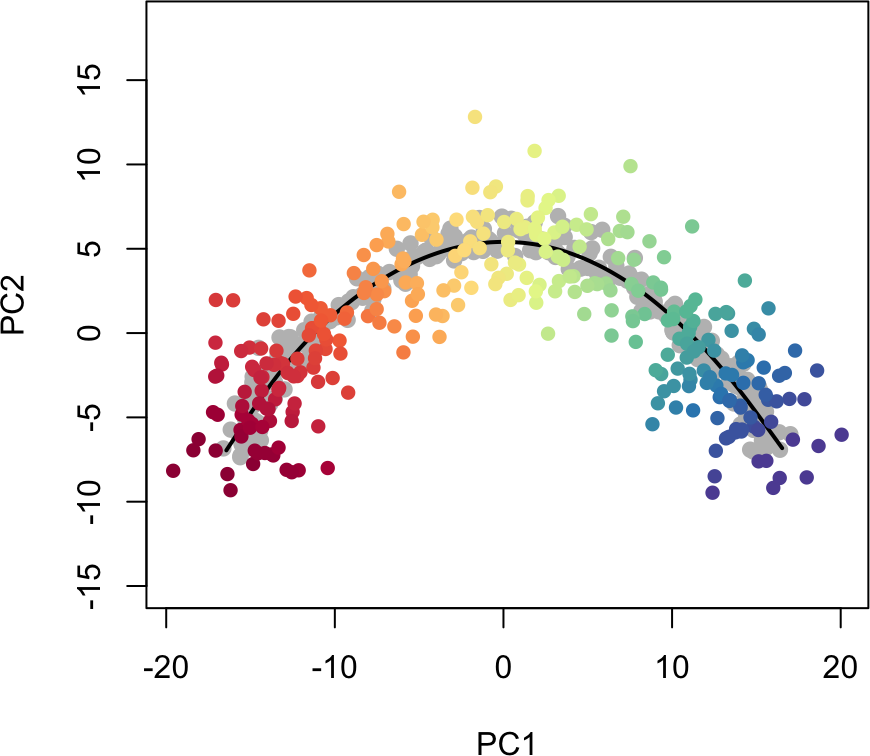

```r
newplotcol <- colors[cut(slingPseudotime(newPTO)[,1], breaks=100)]
plot(reducedDims(sce)$PCA, col = 'grey', bg = 'grey', pch=21, asp = 1,
     xlim = range(newPCA[,1]), ylim = range(newPCA[,2]))
lines(SlingshotDataSet(sce), lwd=2, col = 'black')
points(slingReducedDim(newPTO), col = newplotcol, pch = 16)
```

# References

Cole, Michael, and Davide Risso. 2018. *Scone: Single Cell Overview of Normalized Expression Data*.

Haghverdi, Laleh, Aaron T. L. Lun, Michael D. Morgan, and John C. Marioni. 2018. “Batch effects in single-cell RNA-sequencing data are corrected by matching mutual nearest neighbors.” *Nat. Biotechnol.* 36 (5): 421–27. https://doi.org/10.1038/nbt.4091.

Hastie, Trevor, and Werner Stuetzle. 1989. “Principal Curves.” *Journal of the American Statistical Association* 84 (406): 502–16.

Lun, Aaron, and Davide Risso. 2017. *SingleCellExperiment: S4 Classes for Single Cell Data*.

Risso, Davide, Fanny Perraudeau, Svetlana Gribkova, Sandrine Dudoit, and Jean-Philippe Vert. 2018. “A General and Flexible Method for Signal Extraction from Single-Cell RNA-Seq Data.” *Nature Communications* 9: 284. https://doi.org/10.1038/s41467-017-02554-5.

Scrucca, Luca, Michael Fop, Thomas Brendan Murphy, and Adrian E. Raftery. 2016. “mclust 5: Clustering, Classification and Density Estimation Using Gaussian Finite Mixture Models.” *The R Journal* 8 (1): 205–33.

Street, Kelly, Davide Risso, Russell B Fletcher, Diya Das, John Ngai, Nir Yosef, Elizabeth Purdom, and Sandrine Dudoit. 2017. “Slingshot: Cell Lineage and Pseudotime Inference for Single-Cell Transcriptomics.” *bioRxiv*. https://doi.org/10.1101/128843.

Van den Berge, Koen, Hector Roux de Bézieux, Kelly Street, Wouter Saelens, Robrecht Cannoodt, Yvan Saeys, Sandrine Dudoit, and Lieven Clement. 2020. “Trajectory-Based Differential Expression Analysis for Single-Cell Sequencing Data.” *Nature Communications* 11 (1): 1201. https://doi.org/10.1038/s41467-020-14766-3.